# Coding Cookbook

Bayesian Data Analysis (MA483)

This document provides a list of the code most commonly used in the course. There may be times, especially when working on the class project, when you want to move beyond what is discussed in class. There are many resources available online, or feel free to ask for guidance from the instructor. However, the majority of code needed for the course is documented here.

Throughout this document, we will be making use of the `mtcars` dataset available with all R installations. More information can be found about the variables in this dataset by typing `?mtcars` into your R console or typing `mtcars` into the help search box in RStudio. Here are the first few records of the dataset:

|  | mpg | cyl | disp | hp | drat | wt | qsec | vs | am | gear | carb |
| --- | --- | --- | --- | --- | --- | --- | --- | --- | --- | --- | --- |
| Mazda RX4 | 21.0 | 6 | 160 | 110 | 3.90 | 2.620 | 16.46 | 0 | 1 | 4 | 4 |
| Mazda RX4 Wag | 21.0 | 6 | 160 | 110 | 3.90 | 2.875 | 17.02 | 0 | 1 | 4 | 4 |
| Datsun 710 | 22.8 | 4 | 108 | 93 | 3.85 | 2.320 | 18.61 | 1 | 1 | 4 | 1 |
| Hornet 4 Drive | 21.4 | 6 | 258 | 110 | 3.08 | 3.215 | 19.44 | 1 | 0 | 3 | 1 |
| Hornet Sportabout | 18.7 | 8 | 360 | 175 | 3.15 | 3.440 | 17.02 | 0 | 0 | 3 | 2 |
| Valiant | 18.1 | 6 | 225 | 105 | 2.76 | 3.460 | 20.22 | 1 | 0 | 3 | 1 |

As you progress through the following examples, remember that R is *case sensitive*.

# Basics

Before proceeding to the specific aspects of the course; let’s first talk about a few basics about programming in R.

## Packages

Throughout the course we will be using a standard suite of packages (additional functions which provide additional analytical capabilities). In order to ensure that you have all required functionality for the course, be sure that each RMarkdown file you write has the following block at the top, which should not be altered:

```r
source("https://github.com/reyesem/reyesem.github.io/raw/master/files/MA483/MA483Setup.R")
```

## Anatomy of RMarkdown File

An RMarkdown file is comprised of two components: basic text and “code chunks” which perform the analysis. When the document is compiled (“knit”) the code is evaluated and the results added seemlessly into your document. This encourages a reproducible workflow (someone can recreate all your results should the data change).

Code blocks can be added using the “Insert” button at the top of the script window. Code blocks have the following form:

````
```{r}
Code goes here...
```
````

Notice that the code blocks always begin and end with the triple backticks (found on your keyboard in the upper-left-hand corner with the tilde).

## Anatomy of R Code

Most code chunks all look the same. Below is a very simple code chunk. Objects are “assigned” to an object using an equal sign (or arrow `<-`). The code essentially says that the thing on the left will contain anything generated on the right.

```r
# Comments (not evaluated) begin with a hashtag.
ObjectName <- code to generate results
```

> Just typing the name of an object prints that object out; that output, in turn, will appear in your final document.

If we want to do something to that object, we will make use of the “pipe operator” (`%>%`) which essentially says take the thing before and use it in the next function. For example, we might summarise an object as follows:

```r
ObjectTwo <- ObjectOne %>%
  summarise()
```

This code says take the thing called “ObjectOne” and “pipe it into” (use within) the summarise function; whatever the result of this operation is will be called “ObjectTwo.”

## Creating a Dataset from Scratch

Occasionally, you may need to input data manually (generally, data will be provided to you). This is done using the `tibble()` function. Things to keep in mind include

- Variables are separated by commas.
- Each variable must be named (`Variable_Name =`).
- Values are separated by commas and placed inside the `c()` function.
- Values of a categorical variable are placed inside quotes.

Here is a hypothetical example in which the results of a simple survey are entered into a dataset called `demographics`.

```r
demographics <- tibble(
  `Hair Color` = c("Black", "Black", "Brown", "Blonde", "Black"),
  Age = c(20, 19, 21, 20, 20)
)
```

# Data Manipulation

- `mutate()`: manipulate variables or make transformations.
- `arrange()`: sort a dataset.
- `filter()`: subset the data based on some criteria.

## mutate(): creating or changing variables

As an example, while the US measures fuel efficiency in miles per gallon, other countries often report the gallons required for a single mile. This new variable `Gallons_per_Mile` can be created using `mutate()`:

```r
mtcars <- mtcars %>%
  mutate(Gallons_per_Mile = 1/mpg)
```

Notice that we use the pipe operator (`%>%`) here; this essentially says take the dataset `mtcars` and feed it into the `mutate()` function. The `mutate()` function itself uses the notation `New_Variable_Name = transformation of stuff`. In this case, we create a new variable within the dataset `mtcars`. The result is stored within a dataset called `mtcars` (since that is on the left of the equal sign), essentially overwriting the original dataset.

The first few records of this dataset are shown below:

| mpg | cyl | disp | hp | drat | wt | qsec | vs | am | gear | carb | Gallons_per_Mile |
| --- | --- | --- | --- | --- | --- | --- | --- | --- | --- | --- | --- |
| 21.0 | 6 | 160 | 110 | 3.90 | 2.620 | 16.46 | 0 | 1 | 4 | 4 | 0.048 |
| 21.0 | 6 | 160 | 110 | 3.90 | 2.875 | 17.02 | 0 | 1 | 4 | 4 | 0.048 |
| 22.8 | 4 | 108 | 93 | 3.85 | 2.320 | 18.61 | 1 | 1 | 4 | 1 | 0.044 |
| 21.4 | 6 | 258 | 110 | 3.08 | 3.215 | 19.44 | 1 | 0 | 3 | 1 | 0.047 |
| 18.7 | 8 | 360 | 175 | 3.15 | 3.440 | 17.02 | 0 | 0 | 3 | 2 | 0.053 |
| 18.1 | 6 | 225 | 105 | 2.76 | 3.460 | 20.22 | 1 | 0 | 3 | 1 | 0.055 |

## arrange(): order the data

To sort the data, consider ordering the `mtcars` dataset by the the number of cylinders the car has. This can be done using the `arrange()` function:

```r
mtcars <- mtcars %>%
  arrange(cyl)
```

The results are stored in the `mtcars` dataset (the first few records of which are shown below).

| mpg | cyl | disp | hp | drat | wt | qsec | vs | am | gear | carb | Gallons_per_Mile |
| --- | --- | --- | --- | --- | --- | --- | --- | --- | --- | --- | --- |
| 22.8 | 4 | 108.0 | 93 | 3.85 | 2.320 | 18.61 | 1 | 1 | 4 | 1 | 0.044 |
| 24.4 | 4 | 146.7 | 62 | 3.69 | 3.190 | 20.00 | 1 | 0 | 4 | 2 | 0.041 |
| 22.8 | 4 | 140.8 | 95 | 3.92 | 3.150 | 22.90 | 1 | 0 | 4 | 2 | 0.044 |
| 32.4 | 4 | 78.7 | 66 | 4.08 | 2.200 | 19.47 | 1 | 1 | 4 | 1 | 0.031 |
| 30.4 | 4 | 75.7 | 52 | 4.93 | 1.615 | 18.52 | 1 | 1 | 4 | 2 | 0.033 |
| 33.9 | 4 | 71.1 | 65 | 4.22 | 1.835 | 19.90 | 1 | 1 | 4 | 1 | 0.029 |

## filter(): subsetting a variable

If we only want to look at a subset of the data, we use the `filter()` function. For example, suppose we only want to consider vehicles which have automatic transmissions. Further, we would like to store those in a new dataset called `automatic.only`, we use the following code:

```r
automatic.only <- mtcars %>%
  filter(am == 0)
```

When making comparisons, `==` is asking “are you equal?” We keep the records for which we would anser “yes” to this question. The original `mtcars` dataset is not altered; it remains unchanged. Instead, we have taken it, filtered it down, and then stored the results in `automatic.only` (the first few records of which are shown below).

| mpg | cyl | disp | hp | drat | wt | qsec | vs | am | gear | carb | Gallons_per_Mile |
| --- | --- | --- | --- | --- | --- | --- | --- | --- | --- | --- | --- |
| 24.4 | 4 | 146.7 | 62 | 3.69 | 3.190 | 20.00 | 1 | 0 | 4 | 2 | 0.041 |
| 22.8 | 4 | 140.8 | 95 | 3.92 | 3.150 | 22.90 | 1 | 0 | 4 | 2 | 0.044 |
| 21.5 | 4 | 120.1 | 97 | 3.70 | 2.465 | 20.01 | 1 | 0 | 3 | 1 | 0.047 |
| 21.4 | 6 | 258.0 | 110 | 3.08 | 3.215 | 19.44 | 1 | 0 | 3 | 1 | 0.047 |
| 18.1 | 6 | 225.0 | 105 | 2.76 | 3.460 | 20.22 | 1 | 0 | 3 | 1 | 0.055 |
| 19.2 | 6 | 167.6 | 123 | 3.92 | 3.440 | 18.30 | 1 | 0 | 4 | 4 | 0.052 |

## recode(): Changing the values of a variable

When we work with categorical variables, we often want the values (or group labels) to be something readable. In order to do this, we may need to recode the data. Consider the variable `am` (transmission type). It is currently a 0/1 variable, and it is not obvious that 1 represents manual transmission and 0 automatic transmission. We can make this clearer by mutating the dataset and recoding that variable.

```r
mtcars <- mtcars %>%
  mutate(am = recode(am,
                     `0` = "automatic",
                     `1` = "manual"))
```

| mpg | cyl | disp | hp | drat | wt | qsec | vs | am | gear | carb | Gallons_per_Mile |
| --- | --- | --- | --- | --- | --- | --- | --- | --- | --- | --- | --- |
| 22.8 | 4 | 108.0 | 93 | 3.85 | 2.320 | 18.61 | 1 | manual | 4 | 1 | 0.044 |
| 24.4 | 4 | 146.7 | 62 | 3.69 | 3.190 | 20.00 | 1 | automatic | 4 | 2 | 0.041 |
| 22.8 | 4 | 140.8 | 95 | 3.92 | 3.150 | 22.90 | 1 | automatic | 4 | 2 | 0.044 |
| 32.4 | 4 | 78.7 | 66 | 4.08 | 2.200 | 19.47 | 1 | manual | 4 | 1 | 0.031 |
| 30.4 | 4 | 75.7 | 52 | 4.93 | 1.615 | 18.52 | 1 | manual | 4 | 2 | 0.033 |
| 33.9 | 4 | 71.1 | 65 | 4.22 | 1.835 | 19.90 | 1 | manual | 4 | 1 | 0.029 |

If we now wanted to go further and change “automatic” to “Automatic Transmission”, we could recode again; this time, since the variable is already a phrase, we do not use backticks.

```r
mtcars <- mtcars %>%
  mutate(am = recode(am,
                     "automatic" = "Automatic Transmission",
                     "manual" = "Manual Transmission"))
```

> If your dataset has groups coded as numbers (like above when 0 = automatic and 1 = manual), it is best to recode in order for graphics and models to work appropriately.

# Numerical Summaries

Numerical summaries (statistics) tell us about the distribution of our sample. These also estimate the corresponding parameters of interest in the population. We will primarily use the `skim()` function to summarize all variables in a dataset.

The resulting output is divided up by the type of variables in the dataset. Categorical variables (“characters” and “factors” in R) are summarized differently (counts of each unique value) than numeric variables (mean, percentiles, etc.).

```r
skim(mtcars)
```

```
Skim summary statistics
 n obs: 32
 n variables: 12

-- Variable type:character --------------------------------------------------------------------------
 variable missing complete  n min max empty n_unique              top_counts
       am       0       32 32  19  22     0        2 Aut: 19, Man: 13, NA: 0
 ordered
   FALSE

-- Variable type:numeric ----------------------------------------------------------------------------
         variable missing complete  n    mean      sd     p0     p25     p50
             carb       0       32 32   2.81    1.62   1       2       2
              cyl       0       32 32   6.19    1.79   4       4       6
             disp       0       32 32 230.72  123.94  71.1   120.83  196.3
             drat       0       32 32   3.6     0.53   2.76    3.08    3.7
 Gallons_per_Mile       0       32 32   0.054   0.016  0.029   0.044   0.052
             gear       0       32 32   3.69    0.74   3       3       4
               hp       0       32 32 146.69   68.56  52      96.5   123
              mpg       0       32 32  20.09    6.03  10.4    15.43   19.2
             qsec       0       32 32  17.85    1.79  14.5    16.89   17.71
               vs       0       32 32   0.44    0.5    0       0       0
               wt       0       32 32   3.22    0.98   1.51    2.58    3.33
     p75    p100
   4       8
   8       8
 326     472
   3.92    4.93
   0.065   0.096
   4       5
 180     335
  22.8    33.9
  18.9    22.9
   1       1
   3.61    5.42
```

If you want to create summaries for different subsets of the data, you can first “group” the data using the `group_by()` function. Notice that the summaries of each variable are then computed within each group.

```r
mtcars %>%
  group_by(am) %>%
  skim()
```

```
Skim summary statistics
 n obs: 32
 n variables: 12
 group variables: am

-- Variable type:numeric ----------------------------------------------------------------------------
                     am         variable missing complete  n    mean      sd
 Automatic Transmission             carb       0       19 19   2.74    1.15
 Automatic Transmission              cyl       0       19 19   6.95    1.54
 Automatic Transmission             disp       0       19 19 290.38  110.17
 Automatic Transmission             drat       0       19 19   3.29    0.39
 Automatic Transmission Gallons_per_Mile       0       19 19   0.061   0.015
 Automatic Transmission             gear       0       19 19   3.21    0.42
 Automatic Transmission               hp       0       19 19 160.26   53.91
 Automatic Transmission              mpg       0       19 19  17.15    3.83
 Automatic Transmission             qsec       0       19 19  18.18    1.75
 Automatic Transmission               vs       0       19 19   0.37    0.5
 Automatic Transmission               wt       0       19 19   3.77    0.78
    Manual Transmission             carb       0       13 13   2.92    2.18
    Manual Transmission              cyl       0       13 13   5.08    1.55
    Manual Transmission             disp       0       13 13 143.53   87.2
    Manual Transmission             drat       0       13 13   4.05    0.36
    Manual Transmission Gallons_per_Mile       0       13 13   0.044   0.012
    Manual Transmission             gear       0       13 13   4.38    0.51
    Manual Transmission               hp       0       13 13 126.85   84.06
    Manual Transmission              mpg       0       13 13  24.39    6.17
    Manual Transmission             qsec       0       13 13  17.36    1.79
    Manual Transmission               vs       0       13 13   0.54    0.52
    Manual Transmission               wt       0       13 13   2.41    0.62
      p0     p25     p50     p75    p100
   1       2       3       4       4
   4       6       8       8       8
 120.1   196.3   275.8   360     472
   2.76    3.07    3.15    3.7     3.92
   0.041   0.052   0.058   0.067   0.096
   3       3       3       3       4
  62     116.5   175     192.5   245
  10.4    14.95   17.3    19.2    24.4
  15.41   17.18   17.82   19.17   22.9
   0       0       0       1       1
   2.46    3.44    3.52    3.84    5.42
   1       1       2       4       8
   4       4       4       6       8
  71.1    79     120.3   160     351
   3.54    3.85    4.08    4.22    4.93
   0.029   0.033   0.044   0.048   0.067
   4       4       4       5       5
  52      66     109     113     335
  15      21      22.8    30.4    33.9
  14.5    16.46   17.02   18.61   19.9
   0       0       1       1       1
   1.51    1.94    2.32    2.78    3.57
```

# Graphics

A picture is worth 1000 words. A good graphical summary of the data should not only be a first step in an analysis, but it should also accompany any good analysis to help convey the message of the data. All graphics in this class will be produced with the `qplot()` function. If you are interested in moving beyond what is described here, I would encourage you to look at the `ggplot2` package and would guide you toward the [Ggplot Cheat Sheet](https://www.rstudio.com/wp-content/uploads/2015/03/ggplot2-cheatsheet.pdf). However, all required graphics for this course can be constructed using `qplot()`.

The `qplot()` function has a couple of basic components:

- `data =` specifies the data set in which the variables exist.
- `x =` specifies the variable for the x-axis.
- `y =` if needed, specifies the variable for the y-axis.
- `geom =` determines the way the data is displayed on the graphic.

Additional components allow you to group similar observations based on another variable. The idea is to “map” variables to attributes of the graphic:

- `color =` specifies which variable in the data determines the exterior color of the objects.
- `fill =` specifies which variable in the data determines the fill-color of the objects plotted.
- `size =` specifies which variable in the data determines the size of the objects plotted.
- `shape =` specifies which variable in the data determines the shape of the objects plotted.

In addition to the components above, we can “add” labels using the `labs()` function. As the examples below illustrate, labels are defined by the features set in the graphic command itself (`x`, `y`, `color`, etc.). We now discuss various ways of combining these settings to create common graphics.

## Categorical Variable: Bar Chart

A bar chart is the simplest (and often best) method for summarizing the distribution of a categorical variable. The key steps to making a bar chart include:

1. Place the variable you want to summarize on the x-axis.
2. Set `geom = "bar"`.
3. Note: nothing goes on the y-axis.

For example, we can summarize the number of vehicles with each type of transmission using the following code.

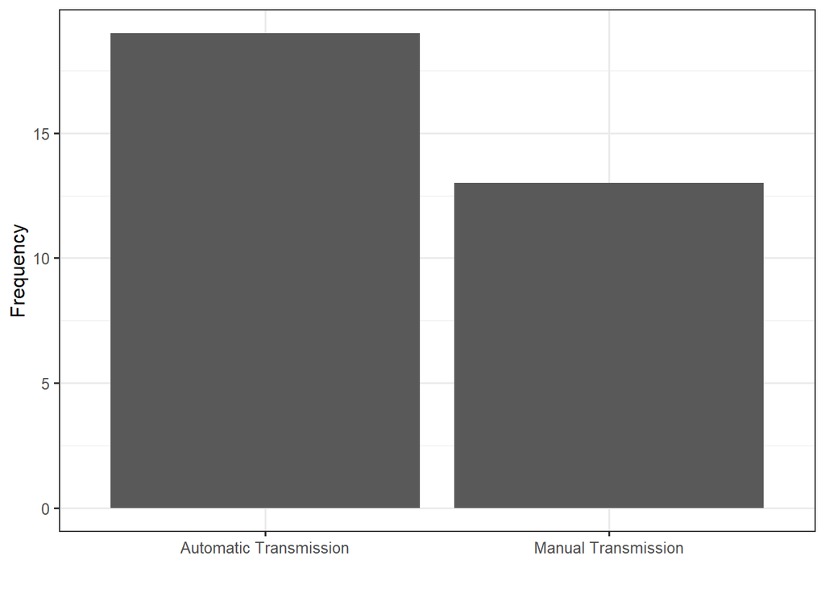

```r
qplot(data = mtcars,
      x = am,
      geom = "bar") +
  labs(x = "",
       y = "Frequency")
```

We remove the label on the x-axis because the value of the variable makes it clear what is being summarized.

## Multiple Categorical Variables: Bar Charts

If you have multiple categorical variables, consider using additional aesthetics to group variables. We will consider a bar chart summarizing the type of engine and the type of transmission for each vehicle. First, we clean up the way that the variable `vs` is coded:

```r
mtcars = mtcars %>%
  mutate(vs = recode(vs,
                     `0` = "V Engine",
                     `1` = "Straight Engine"))
```

Now, we construct the graphic using the following steps:

1. Place primary variable of interest on x-axis.
2. Use `fill =` to set the secondary variable.
3. Use `geom = "bar"`.

Again, we remove the labels of both the `fill` and the `x` variables because the values are self-evident.

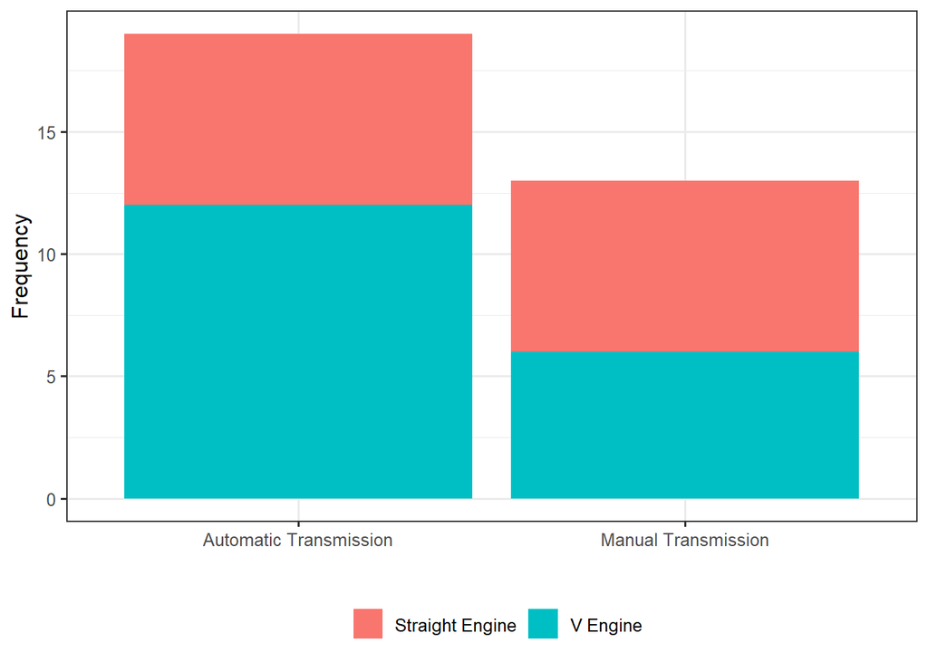

```r
qplot(data = mtcars,
      x = am,
      fill = vs,
      geom = "bar") +
  labs(x = "",
       fill = "",
       y = "Frequency")
```

## Quantitative Variable: Histogram

When looking at the distribution of a single variable, a histogram is a reasonable choice, especially for medium-sized datasets.

1. Set the variable to summarize on the x-axis.
2. Choose `geom = "histogram"`.
3. Set the `binwidth =` option to a reasonable size (how large do you want each bin to be). This changes for each problem and is a matter of opinion on what gives a reasonable looking graphic.

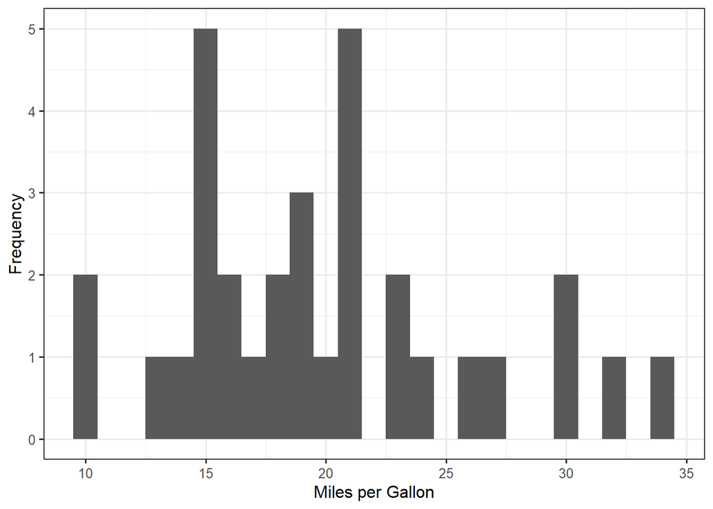

```r
qplot(data = mtcars,
      x = mpg,
      geom = "histogram",
      binwidth = 1) +
  labs(x = "Miles per Gallon",
       y = "Frequency")
```

In this graphic, we set the binwidth to be 1. We could also have considered a larger binwidth of 3, for example:

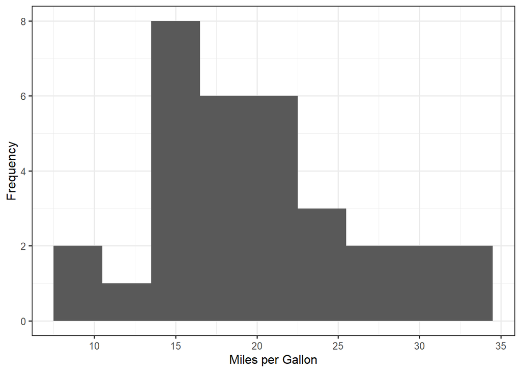

```r
qplot(data = mtcars,
      x = mpg,
      geom = "histogram",
      binwidth = 3) +
  labs(x = "Miles per Gallon",
       y = "Frequency")
```

If you exclude the `binwidth =` option, it will choose a value for you:

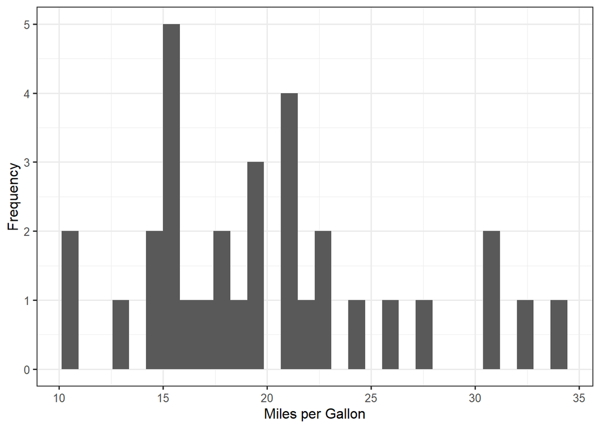

```r
qplot(data = mtcars,
      x = mpg,
      geom = "histogram") +
  labs(x = "Miles per Gallon",
       y = "Frequency")
```

## Quantitative Variable: Density

A density plot is like a smooth histogram; this works best with larger datasets.

1. Set the variable to summarize on the x-axis.
2. Choose `geom = "density"`

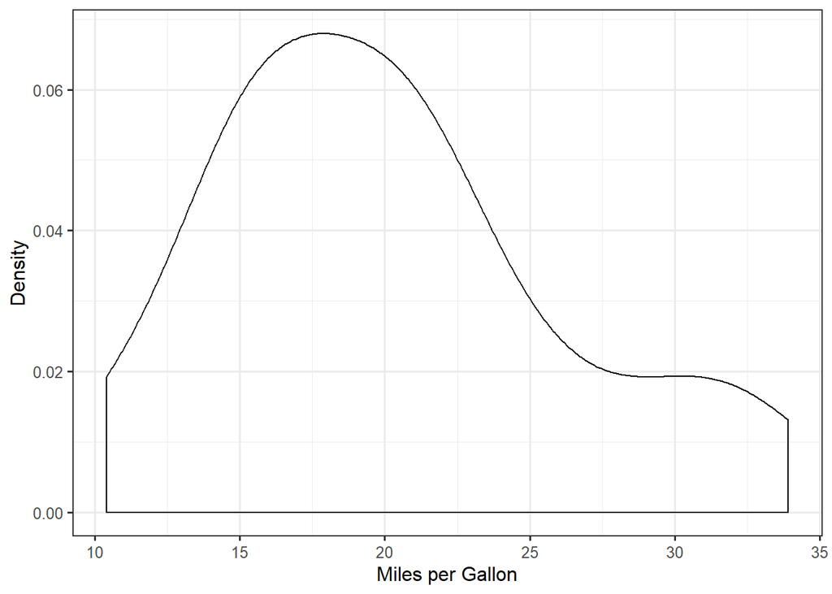

```r
qplot(data = mtcars,
      x = mpg,
      geom = "density") +
  labs(x = "Miles per Gallon",
       y = "Density")
```

The y-axis on this graphic is not directly interpretable; essentially they have been chosen such that the area under the curve is equal to 1. Our primary interest here is that larger values mean the values on the x-axis are more likely.

## Quantitative Variable: Boxplot

A boxplot gives a quick summary of location and spread for a numeric variable.

1. Set the variable to summarize on the y-axis.
2. Set the x-axis to be empty: "".
3. Choose `geom = "boxplot"`

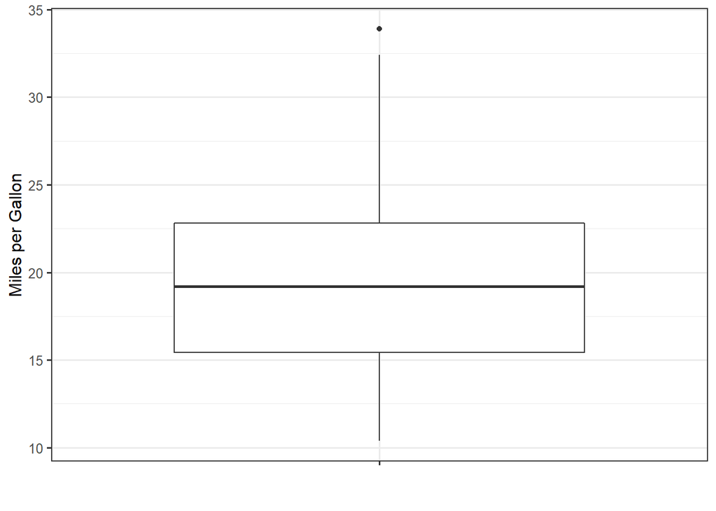

```r
qplot(data = mtcars,
      y = mpg,
      x = "",
      geom = "boxplot") +
  labs(y = "Miles per Gallon",
       x = "")
```

## Quantitative Variable Across Groups: Boxplots

If we are examining the distribution of a quantitative variable across various groups formed by a categorical variable, we can use side-by-side graphics, such as boxplots.

1. Set the variable to be summarized on the y-axis.
2. Place the grouping variable on the x-axis.
3. Set `geom = "boxplot"`.

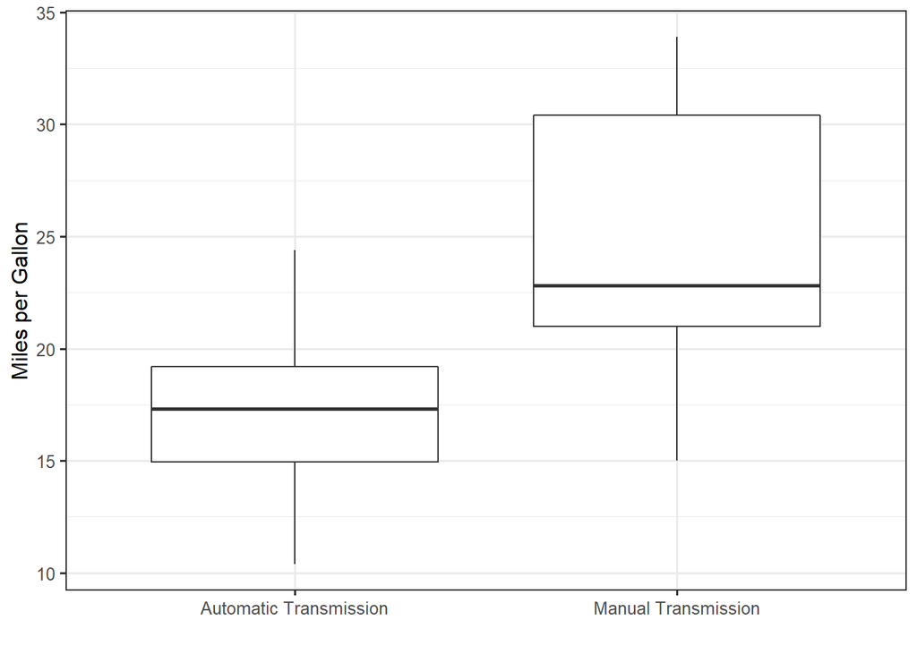

```r
qplot(data = mtcars,
      y = mpg,
      x = am,
      geom = "boxplot") +
  labs(x = "",
       y = "Miles per Gallon")
```

## Quantitative Variable Across Groups: Violin Plots

Boxplots summarize the center and spread of the data, but the shape is lost. Violin plots generalize boxplots by incorporating the shape.

1. Set the variable to be summarized on the y-axis.
2. Place the grouping variable on the x-axis.
3. Set `geom = "violin"`.

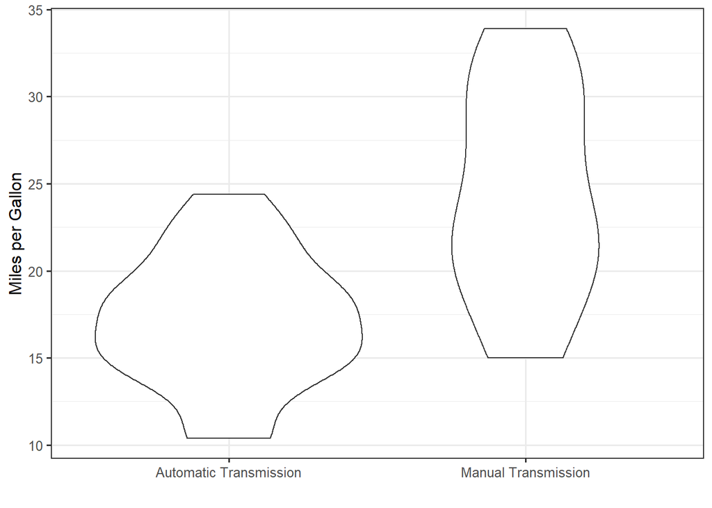

```r
qplot(data = mtcars,
      y = mpg,
      x = am,
      geom = "violin") +
  labs(x = "",
       y = "Miles per Gallon")
```

## Quantitative Variable Across Groups: Individual Value Plots

When we have a small sample, boxplots are inappropriate because they hide the raw data and present an overly confident summary. Instead, we prefer to place the raw values on the plot.

1. Set the variable to be summarized on the y-axis.
2. Place the grouping variable on the x-axis.
3. Set `geom = "point"`.

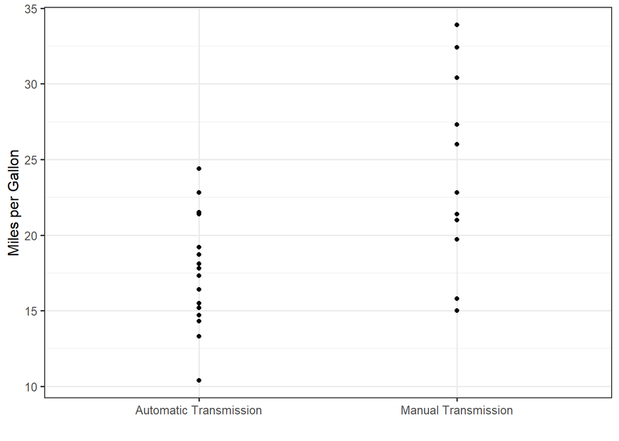

```r
qplot(data = mtcars,
      y = mpg,
      x = am,
      geom = "point") +
  labs(x = "",
       y = "Miles per Gallon")
```

If it looks too overwhelming because you have just enough points that they overlap, you can “jitter” the points:

1. Set the variable to be summarized on the y-axis.
2. Place the grouping variable on the x-axis.
3. Set `geom = "jitter"`.
4. Set `height = 0` to prevent the data from being jittered vertically.

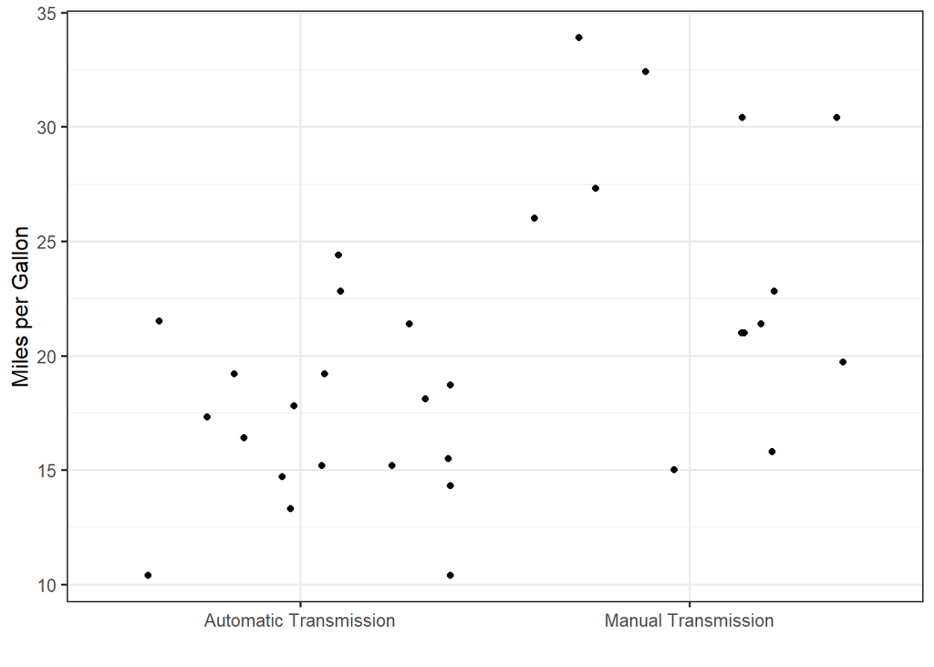

```r
qplot(data = mtcars,
      y = mpg,
      x = am,
      geom = "jitter",
      height = 0) +
  labs(x = "",
       y = "Miles per Gallon")
```

## Quantitative Variable Across Multiple Groups

Boxplots, Violin Plots, and Individual Value Plots can all be extended to include additional other groups by adding aesthetics. For example, we can construct a side-by-side boxplot which also fills according to the engine type.

1. Set variable to be summarized on the y-axis.
2. Set the primary grouping variable on the x-axis.
3. Set the secondary grouping variable as an aesthetic (`fill =`, `color =`, etc.)
4. Set `geom = "boxplot"` for example.

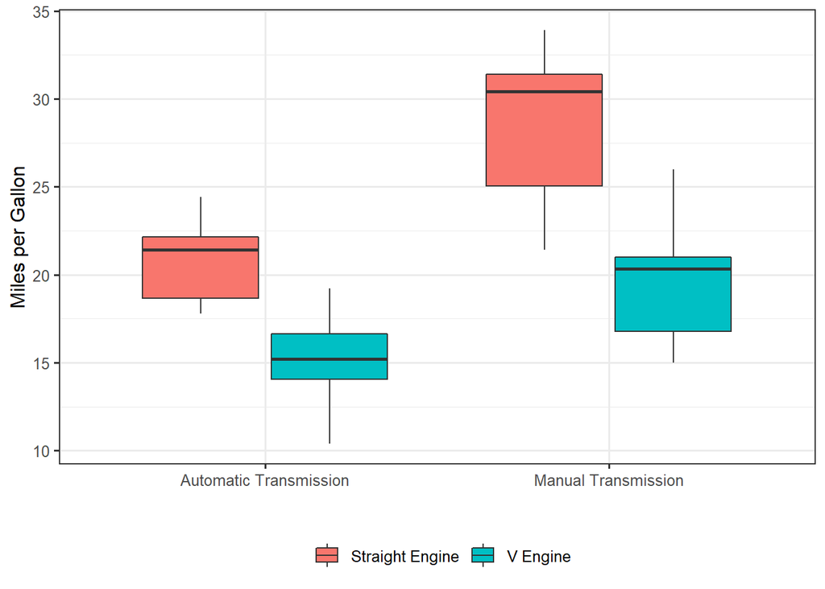

```r
qplot(data = mtcars,
      y = mpg,
      x = am,
      fill = vs,
      geom = "boxplot") +
  labs(x = "",
       y = "Miles per Gallon",
       fill = "")
```

## Two Quantitative Variables: Scatterplot

When examining the relationship between two quantitative variables, we can use a scatterplot.

1. Set the response (variable to be explained or predicted) on the y-axis.
2. Set the predictor (the “given” information) on the x-axis.
3. Set `geom = "point"`.

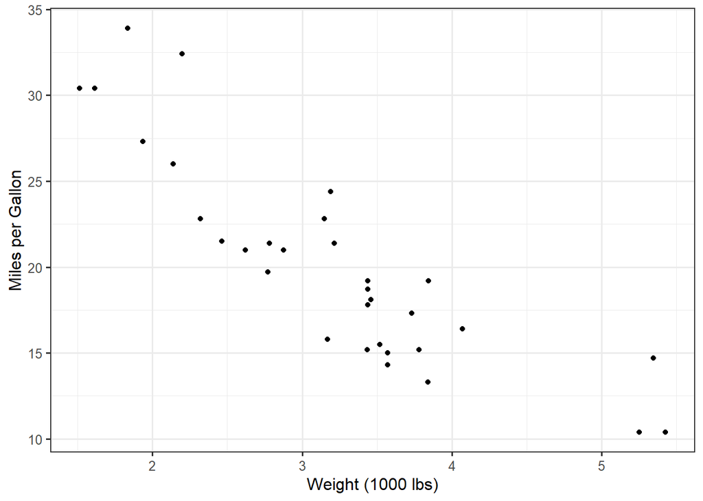

```r
qplot(data = mtcars,
      y = mpg,
      x = wt,
      geom = "point") +
  labs(y = "Miles per Gallon",
       x = "Weight (1000 lbs)")
```

## Adding Features to Scatterplots

Just as with other plots, we can add additional features to a scatterplot. In general, the following two guiding principles help when thinking about these additional aesthetics:

- Groups are best distinguished using color or shape.
- Quantitative variables are captured using color or size.

The following graphic examines the relationship between the fuel efficiency (MPG) of a vehicle and its weight, while also considering the transmission type of the vehicle. Since “transimission type” is categorical, we use the color to separate these groups.

1. Set the response (variable to be explained or predicted) on the y-axis.
2. Set the predictor (the “given” information) on the x-axis.
3. Set the grouping variable using `color =`.
4. Set `geom = "point"`.

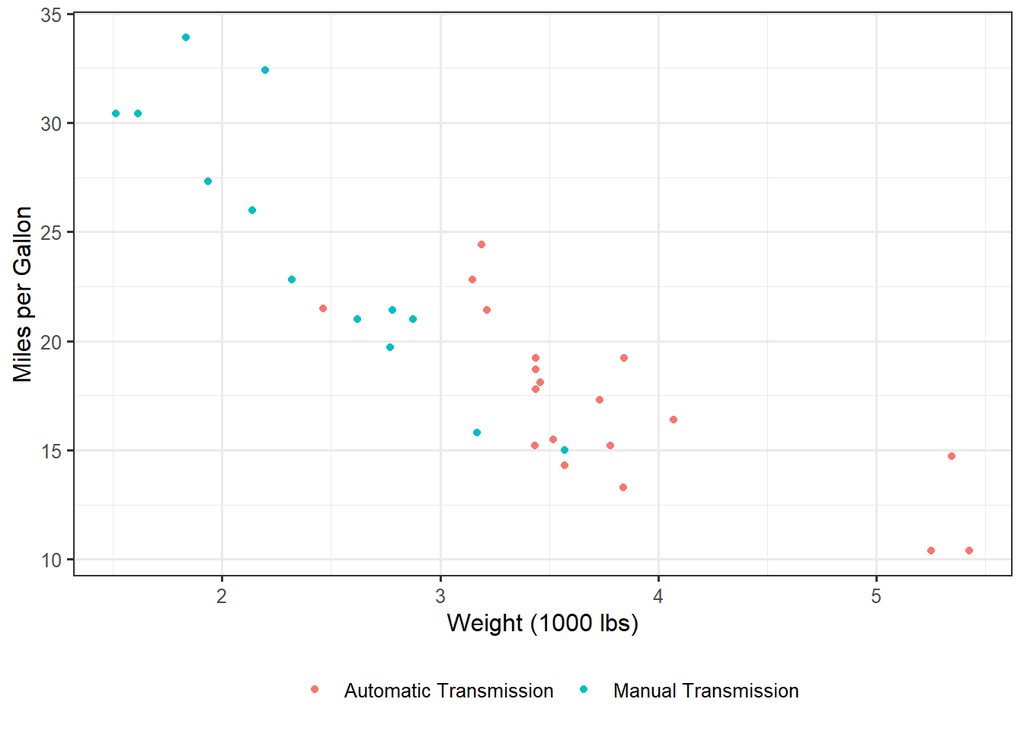

```r
qplot(data = mtcars,
      y = mpg,
      x = wt,
      color = am,
      geom = "point") +
  labs(y = "Miles per Gallon",
       x = "Weight (1000 lbs)",
       color = "")
```

We could also have used shape of the points instead.

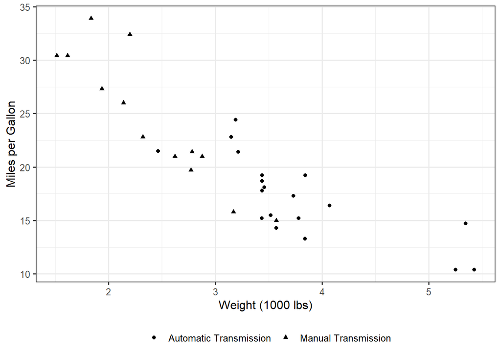

```r
qplot(data = mtcars,
      y = mpg,
      x = wt,
      shape = am,
      geom = "point") +
  labs(y = "Miles per Gallon",
       x = "Weight (1000 lbs)",
       shape = "")
```

If we want to look at the relationship between the fuel efficiency (MPG) of a vehicle and its weight, while also considering its horsepower, we do things a bit differently. Since “horsepower” is quantitative, we can use color or size to distinguish between various values. Both versions are shown below.

1. Set the response (variable to be explained or predicted) on the y-axis.
2. Set the predictor (the “given” information) on the x-axis.
3. Set the secondary predictor using `color =`.
4. Set `geom = "point"`.

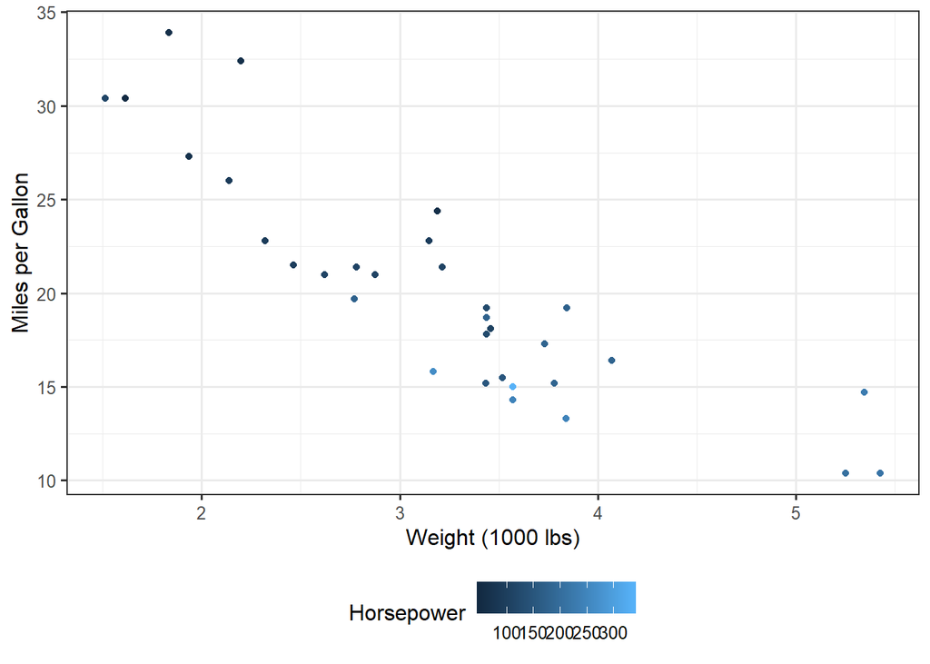

```r
qplot(data = mtcars,
      y = mpg,
      x = wt,
      color = hp,
      geom = "point") +
  labs(y = "Miles per Gallon",
       x = "Weight (1000 lbs)",
       color = "Horsepower")
```

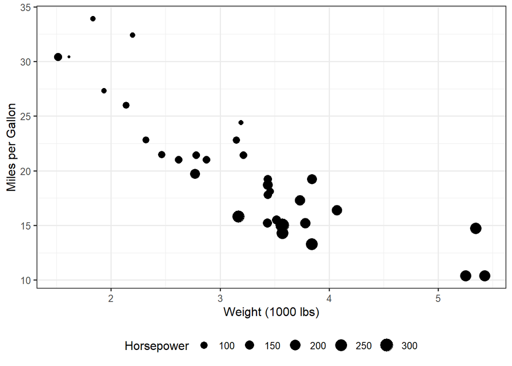

```r
qplot(data = mtcars,
      y = mpg,
      x = wt,
      size = hp,
      geom = "point") +
  labs(y = "Miles per Gallon",
       x = "Weight (1000 lbs)",
       size = "Horsepower")
```

# Common Distributions in R

R has lots of distributions built-in. A list of popular ones, along with their parameterizations is given in the following table.

| Distribution | Function | Form of Density |
| --- | --- | --- |
| Beta | `dbeta` | $\frac{\Gamma(a+b)}{\Gamma(a)\Gamma(b)} x^{a-1}(1-x)^{b-1}$ |
| Binomial | `dbinom` | $\binom{n}{x}p^x(1-p)^{n-x}$ |
| Cauchy | `dcauchy` | $\frac{1}{\pi s (1 + ((x - l)/s)^2)}$ |
| Chi-Squared | `dchisq` | $\frac{1}{2^{n/2}\Gamma(n/2)} x^{(n/2) - 1}e^{-x/2}$ |
| Exponential | `dexp` | $\lambda e^{-\lambda x}$ |
| F | `df` | $\frac{\Gamma\left(\left(n_1+n_2\right)/2\right)}{\Gamma\left(n_1/2\right) \Gamma\left(n_2/2\right)} \left(\frac{n_1}{n_2}\right)^{n_1/2} x^{(n_1/2) - 1} \left(1 + \left(\frac{n_1}{n_2}\right)x\right)… |
| Gamma | `dgamma` | $\frac{1}{s^a \Gamma(a)} x^{a-1}e^{-(x/s)}$ |
| Geometric | `dgeom` | $p (1-p)^x$ |
| Hypergeometric | `dhyper` | $\frac{\binom{m}{x} \binom{n}{k-x}}{\binom{m+n}{k}}$ |
| Log-Normal | `dlnorm` | $\frac{1}{\sigma x \sqrt{2\pi}} e^{-\left(\frac{(\log(x) - \mu)^2}{2\sigma^2}\right)}$ |
| Multinomial | `dmultinom` | $\frac{\left(\sum_{j=1}^K x_j\right)!}{\prod_{j=1}^K x_j!} \prod_{j=1}^K p_j x_j$ |
| Negative Binomial | `dnbinom` | $\frac{\Gamma(x+n)}{\Gamma(n) x!} p^n (1-p)^x$ |
| Normal | `dnorm` | $\frac{1}{\sigma\sqrt{2\pi}} e^{-\left(\frac{(x-\mu)^2}{2\sigma^2}\right)}$ |
| Poisson | `dpois` | $\frac{\lambda^x e^{-\lambda}}{x!}$ |
| Student’s t | `dt` | $\frac{\Gamma((n+1)/2)}{\sqrt{n\pi} \Gamma(n/2)} \left(1 + \frac{x^2}{n}\right)^{-((n+1)/2)}$ |
| Uniform | `dunif` | $\frac{1}{\text{max} - \text{min}}$ |
| Weibull | `dweibull` | $\left(\frac{a}{b}\right)\left(\frac{x}{b}\right)^{a-1} e^{-(x/b)^a}$ |

If you use any of these functions, **be sure to check that the parameterization you want matches that in R**. Not all programs parameterize distributions the same way (for example, R parameterizes the Normal distribution in terms of the standard deviation, while we often write it in terms of the variance). For each distribution, there are actually four functions of interest:

- `dxxx`: computes the value of the density function. For continuous random variables, this is not typically helpful. For discrete random variables, this is the probability of being equal to the value.
- `pxxx`: the CDF, giving the probability of being less than or equal to a value.
- `qxxx`: the inverse CDF; so, given a probability, give the corresponding quantile.
- `rxxx`: randomly generate a sample from this distribution.

For example, `pnorm(3, mean = 0, sd = 2)` will return $Pr(Z \leq 3)$ where $Z \sim N(0, 4)$. Each function has a different set of arguments based on the parameters of the corresponding distribution.

# Simple Operations with Functions

For very simple problems, we can make use of basic functionality in R. These could also be accomplished in other computing environments such as Maple or Matlab if you prefer.

## Writing Functions

Writing functions in R could be its own text. Indeed, several have been written on the subject. We will just give the basic components of writing a function in R. This is helpful if the distribution you want to work with is not specified in R already.

For example, suppose we want to define the triangular distribution in R, which has the following density function

$$f(x) = \begin{cases} \frac{2 (x - a)}{(b - a)(\mu - a)} & a \leq x \leq \mu \\
\frac{2(b - x)}{(b - a)(b - \mu)} & \mu < x \leq b \end{cases} \qquad a \leq x \leq b$$

which has parameters $a \in \mathbb{R}$, $b > a$, and $a < \mu < b$. If we wanted to write a function called `dtriangular` that returned the value of this density function, we could code it as follows:

```r
dtriangular <- function(x, params){
  a <- params[1]
  mu <- params[2]
  b <- params[3]

  f <- ifelse(x <= mu,
              (2 * (x - a)) / ((b - a) * (mu - a)),
              (2 * (b - x)) / ((b - a) * (b - mu)))

  f <- ifelse((x < a) | (x > b), 0, f)

  f
}
```

While this function is relatively simple, it illustrates several key ideas about writing functions in R.

1. Functions are created by a call to `function()`. We use `function_name <- function()` to create a function called `function_name`.
2. Inside `function()` are the list of arguments to the function (sometimes called parameters, but we do not want to confuse that with parameters of a distribution). In the above example, there are two arguments, `x`, the value at which we want to compute the density and `params` a *vector* of values giving the parameters. So, arguments can be a mix of data types.
3. The body of the function is defined inside curly braces `{}`. Any R code is allowed within the function.
4. The function returns the last object stated inside; in this case, `f` is called as the last thing; so, it returns the value of `f`.
5. Functions work like math functions; they take inputs and return outputs. They do *not* alter the original inputs.
6. Functions, when possible, should be vectorized. This is a subtle point. Notice that the value `x` passed to the function does not need to be a single number, it could be a vector of numbers and the function would still work. This allows for more efficiency. Generally, this is not too hard to do, but every once in a while, it requires clever thinking. In our case, we used `ifelse()` in order to check the bounds for each value in the vector `x`.

As an aside, also notice that inside the function, we indexed the `params` vector. Indexing in R begins with 1.

We could now call our function with the following:

```r
dtriangular(3, params = c(0, 3, 6))
```

```
[1] 0.3333333
```

```r
dtriangular(c(0.25, 0.5, 0.75), params = c(0, 0.5, 1))
```

```
[1] 1 2 1
```

## Integrating a Function

Once we have defined a function, we can integrate it. For example, consider the triangular distribution defined in the previous section. Suppose, we have $X \sim tri(0, 0.5, 1)$ and we are interested in $Pr(X < 0.25)$; then, this is computed by

$$\int_{0}^{0.25} f(x) dx$$

This is simple to do by hand, but we can implement this in R using our function from before. Integration will be performed using the `integrate()` function, which has the following key arguments:

- `f`: the name of the function to integrate.
- `lower`: the lower bound of integration (`-Inf` is allowed).
- `upper`: the upper bound of integration (`Inf` is allowed).

There are other arguments, but these are the most important. In addition, any arguments that must be specified for the function being integrated should also be included.

Note: for integration, it is important that the function was written to handle a vector.

```r
integrate(dtriangular, lower = 0, upper = 0.25,
          params = c(0, 0.5, 1))
```

```
0.125 with absolute error < 1.4e-15
```

Here, we pass the arguments `params = c(0, 0.5, 1)` to R in addition to the bounds of integration.

## Finding a Root

Here, we illustrate a simple case of finding the root of a function; that is, we are solving a single nonlinear equation. Suppose we want to find the value of $q$ such that $1 = f(q)$ where $f$ is the density function for a triangular distribution with $a = 0, \mu = 0.5, b = 1$. Root finding assumes you are solving an equation that is equal to 0. So, we rewrite this as

$$0 = g(q) = f(q) - 1$$

Therefore, we write a function `zerofct` for which we would want to set it equal to 0 to solve our problem.

```r
zerofct <- function(x){
  1 - dtriangular(x, params = c(0, 0.5, 1))
}
```

Now, we can use the `uniroot()` function to actually obtain the root. The key arguments are

- `f`: the name of the function to solve.
- `lower`: the lower bound to an interval that contains our root.
- `upper`: the upper bound to an interval that contains our root.

Note that for this method to work, we must have an idea of a region in which the root occurs. Here, it is logical that a root would occur between the lower end of the support and the mode of the distribution $\mu$. Therefore, we search between $0, 0.5$.

```r
uniroot(zerofct, lower = 0, upper = 0.5)
```

```
$root
[1] 0.25

$f.root
[1] 0

$iter
[1] 1

$init.it
[1] NA

$estim.prec
[1] 0.25
```

For solving a system of nonlinear equations, look at the Optimization section.

## Optimization

Consider once again our triangular distribution. In particular, suppose $X \sim tri(0, 0.5, 1)$. Now, from the form of the distribution, we know the mode (value at which the density is maximized) is given at 0.5 — the value of the parameter $\mu$. Let’s pretend for a moment we did not know that. Instead, we simply know that a mode exists somewhere in the support.

Finding the mode is equivalent to maximizing the density function. In optimization, most problems are framed in terms of minimization; however, switching is easy. If you want to find the value of $x$ which maximizes $g(x)$, that is equivalent to finding the value of $x$ which minimizes $-g(x)$. So, we first write a function that switches the sign:

```r
minfct <- function(x){
  -dtriangular(x, params = c(0, 0.5, 1))
}
```

Now, we use the function `optim()` to perform the optimization. There are a couple of key arguments:

- `par`: the first argument is the *initial value* for the parameter (our best guess).
- `fn`: the name of the function to optimize.
- `method`: most cases, you can accept the default; if you are doing one-dimensional optimization, we need to specify `method = "Brent"`.
- `lower`: only needed if `method = "Brent"`; specifies the lower bound of an interval containing the optimal point.
- `upper`: only needed if `method = "Brent"`; specifies the upper bound of an interval containing the optimal point.

Since we are doing one-dimensional optimization (only looking over a single argument of the function), we will use `method = "Brent"`, and we will also set an interval; we believe the mode is in the support $0, 1$.

```r
optim(par = 0.25, fn = minfct, method = "Brent", lower = 0, upper = 1)
```

```
$par
[1] 0.5

$value
[1] -2

$counts
function gradient
      NA       NA

$convergence
[1] 0

$message
NULL
```

In this example, we started with a best guess of 0.25, and it resulted in finding the optimal point of 0.5 (as we should hope since we knew that to be the answer). Notice that we need to ensure that convergence actually occurred (the `convergence` value is 0).

One application of optimization is solving a system of nonlinear equations. For example, let $X \sim N\left(\mu, \sigma^2\right)$. Suppose we want to find the values of $\mu$ and $\sigma$ such that

$$\begin{aligned}
0.05 &= Pr(X < 0) = \int_{-\infty}^{0} f(x \mid \mu, \sigma) dx \\
0.05 &= Pr(X > 100) = \int_{100}^{\infty} f(x \mid \mu, \sigma) dx
\end{aligned}$$

where we have written the density function to express that it is a function of the parameters $\mu$ and $\sigma$. There is not a function in R for solving a system of nonlinear equations. However, consider the function

$$g(x \mid \mu, \sigma) = \left[0.05 - \int_{-\infty}^{0} f(x \mid \mu, \sigma)dx\right]^2 + \left[0.05 - \int_{100}^{\infty} f(x \mid \mu, \sigma) dx\right]^2.$$

Observe that the function $g$ is non-negative; therefore, it is minimized when the system of equations above is met. So, solving the system of equations is equivalent to minimizing $g$ *as a function of the parameters* $\mu$ and $\sigma$. First, we write the function $g$ into R:

```r
gfct <- function(params){
  mu <- params[1]
  sigma <- params[2]

  f1 <- pnorm(0, mean = mu, sd = sigma)
  f2 <- 1 - pnorm(100, mean = mu, sd = sigma)

  (0.05 - f1)^2 + (0.05 - f2)^2
}
```

Now, we use `optim()` to perform the minimization where our initial values consider setting the mean to be right between 0 and 100, and taking the standard deviation to be 15.

```r
optim(par = c(50, 15), fn = gfct)
```

```
$par
[1] 50.00026 30.39766

$value
[1] 3.579684e-12

$counts
function gradient
      61       NA

$convergence
[1] 0

$message
NULL
```

We find that taking $\mu = 50$ and $\sigma \approx 30.4$ results in a solution to the system.

# Monte Carlo Integration

Monte Carlo Integration is a numerical integration technique that relies on the idea that large samples produce statistics that are good approximations of their corresponding parameters. Essentially, it relies on the idea that

$$\frac{1}{m} \sum_{i=1}^{m} g\left(X_i\right) \approx \int g(x) f(x) dx$$

if $X_1, X_2, \dotsc, X_m$ represents a random sample with density $f(x)$.

As an example, suppose we are interested in estimating $E(X \mid X > 5)$, where $X$ follows an exponential distribution with rate parameter 0.5. Such tail expectations are common in actuarial science. We can estimate this quantity with the following code:

```r
# Generate from Exponential
x <- rexp(10000, rate = 0.5)

# Filter appropriately, then take mean
mean(x[x > 5])
```

```
[1] 6.995181
```

In the above code, we use the `[]` to perform indexing on the vector `x`. So, we are selecting those elements of `x` which are larger than 5.

# Markov Chain Monte Carlo (MCMC)

Implementing MCMC algorithms requires specialized software, which in turn means learning a new way of syntactically representing the model for the computer. In this class, we will be implementing a Hamiltonian Monte Carlo (HMC) procedure through Stan in order to obtain a sample from the posterior. As this is very problem-dependent, we will be focusing on the workflow here. It is important to make use of the [Stan Reference Manual](https://mc-stan.org/docs/2_21/stan-users-guide/index.html).

In brief, models are specified in a special block in an RMarkdown file. When executed, this block is translated to C++ code which will control the generation. As a result, compiling this block of code can take quite some time as it must specify all the generation steps within the HMC algorithm including gradients for the potential. After compiling the Stan code, we use R to read the stored code and perform the sampling and summaries.

**Hint (optional):** These models take a long time to compile; you only need to compile them once per session (unless you make a change). There is a way to save the compiled version if you need to come back to it in a different session. Below is the workflow:

1. Create a `stan` block within RMarkdown. Use the `output.var =` block option to specify a name in which to store the compiled Stan code. Also, specify `eval = FALSE` in the block options because the code only needs to be compiled once; that will probably occur at the time of development and need not be done at the time of knitting the document.
2. Create an `r` block within RMarkdown. Use the `saveRDS()` function in order to store the code that was compiled in the previous block. Again, specify `eval = FALSE` in the block options to avoid this being done at the time the document is knitted.
3. Create an `r` block within RMarkdown. Use the `readRDS()` function in order to read the compiled code into your workspace. You cannot have two compiled versions of the same code within a session; so, this block should only be executed when knitting the document.

It is possible to skip steps 2 and 3 (hence the optional aspect), but it will making knitting documents take much longer. Below are examples for each step.

Step 1: Creating a Stan block. This stores the compiled code in your workspace.

````
```{stan, output.var = "stanModelName", eval = FALSE}
// Put Stan code here...
// Running this block compiles the code.
```
````

Step 2: Saving the Stan block. This writes the code to a file in the same working directory as your RMarkdown document.

````
```{r, eval = FALSE}
saveRDS(stanModelName, "stanModelName.rds")
```
````

Step 3: Reading the Stan code. This reads the Stan code during the knitting process.

````
```{r}
stanModelName <- readRDS("stanModelName.rds")
```
````

As we proceed, consider the data in the `cars` dataset (pre-loaded in R). The data consists of 50 observations in which the stopping vehicle of a vehicle was determined, along with the speed at which the car was traveling when it braked. The data consists of two variables:

- `speed`: the speed (mph) the car was traveling at the time the brakes were applied.
- `dist`: the stopping distance (feet) of the car.

This data was taken in the 1920s and is therefore outdated. However, it will serve to illustrate our approach to MCMC sampling. Suppose we would like to consider the following model:

$$\begin{aligned}
Y_i &\stackrel{IID}{\sim} Exp(\lambda) \\
\lambda &\sim Gamma(1, 1)
\end{aligned}$$

where $Y_i$ is the stopping distance for the $i$-th car, where $i$ takes values between 1 and 50. We must write this model in the Stan langauge using a `stan` block.

Within the `stan` block, the Stan code must contain the following components:

- `data`: specifies the *type* of data you intend to pass to the program.
- `transformed data` (optional): specifies any pre-processing of the data.
- `parameters`: specifies the support of the parameters.
- `transformed parameters` (optional): specifies pre-processing of parameters and adds them to the list of the parameters we keep track of. Transformations defined in the model are not tracked.
- `model`: specifies the likelihood and prior.

A few additional things to keep in mind:

- `Each line *must* end with a semicolon.
- Each variable must have a type associated with it; bounds are optional.
- Comments are denoted by `//`.
- The code is vectorized when specifying the model.

For our example, we have the following block (not shown here is setting `output.var = "codingCookbookStan"` in the block options).

```stan
data{
  int<lower = 0> n; // three parts: type<bound, if applicable> value[array]
  real<lower = 0> y[n];
}

parameters{
  real<lower = 0> lambda;
}

model{
  lambda ~ gamma(1, 1); // define prior first
  y ~ exponential(lambda); // note the vectorization of the responses
}
```

Note: there are many ways to specify models; the above illustrates the most simple form, which mimics how we write models by hand. Other methods are more useful for complex models; refer to the Stan documentation.

If we wanted to save this output and read it in later, we could add R blocks that save the compiled code and reads it back into our working directory as follows:

```r
saveRDS(codingCookbookStan, "codingCookbookStan.rds")
```

```r
codingCookbookStan <- readRDS("codingCookbookStan.rds")
```

The above `stan` block just saves the compiled code; it does not actually perform the sampling. We need an additional R block to run the code.

- The data must be defined as a *list* in R.
- The function `stan()` is used to call the code and pass in the data. Notice that the code is actually stored within a “slot” in the stored code. That is, use `nameOfModel@model_code` in order to access that code.

In the below block, we save the relevant data from the `cars` dataset into a list `dataList`. We then pass that data, and the model code from `codingCookbookStan` object to the `stan()` function. Depending on the options specified, the `stan()` function can take several minutes to run as it is performing the MCMC resampling.

```r
# Define data as a named list
dataList <- list(n = nrow(cars),
                 y = cars$dist)

# Grab "model_code" out of Stan file object
fit <- stan(model_code = codingCookbookStan@model_code,
            data = dataList,
            chains = 4,
            iter = 2000,
            warmup = 1000,
            thin = 1)

fit
```

```
Inference for Stan model: stan-e081fb25e1b.
4 chains, each with iter=2000; warmup=1000; thin=1;
post-warmup draws per chain=1000, total post-warmup draws=4000.

          mean se_mean   sd    2.5%     25%     50%     75%   97.5% n_eff Rhat
lambda    0.02    0.00 0.00    0.02    0.02    0.02    0.03    0.03  1598    1
lp__   -242.31    0.02 0.71 -244.37 -242.48 -242.03 -241.86 -241.81  1921    1

Samples were drawn using NUTS(diag_e) at Mon Jan 20 11:29:24 2020.
For each parameter, n_eff is a crude measure of effective sample size,
and Rhat is the potential scale reduction factor on split chains (at
convergence, Rhat=1).
```

Note that there are endless options you might give to `stan()`, but the arguments we will most often use are

- `chains =`: the number of independent chains to generate.
- `iter =`: the number of iterations *per chain*, including the burn-in period.
- `warmup =`: the burn-in period *per chain*.
- `thin =`: the amount of thinning to perform *per chain* (a value of 1 indicates no thinning, and is the default).

The last line of the block (`fit`), simply prints the object you created with the call to `stan()`. This contains various summaries of the different parameters. We generally ignore the log of the posterior (`lp__` in the output) and focus on the parameters of interest in our problem. The posterior mean, posterior standard deviation, and various quantiles are summarized, along with the effective sample size and R-hat value.

## Visualizing the Posterior

The default output from `stan()` is sufficient for a point estimation, but to examine diagnostics about the MCMC sampling scheme or compute probabilities from the posterior, we need the actual values sampled. For this, we will use the `stan_to_df()` function, which is custom-written for this course (alternatives are provided by the `rstan` package, but do not place the results in as nice of a framework).

```r
params <- stan_to_df(fit)
```

The result is a data set containing all the values sampled. Now, we could compute $Pr(\lambda < 0.02 \mid \mathbf{y})$, for example:

```r
params %>%
  summarise(Prob = mean(lambda < 0.02))
```

```
# A tibble: 1 x 1
   Prob
  <dbl>
1 0.129
```

We could also form a density estimate of the posterior distribution using this dataset:

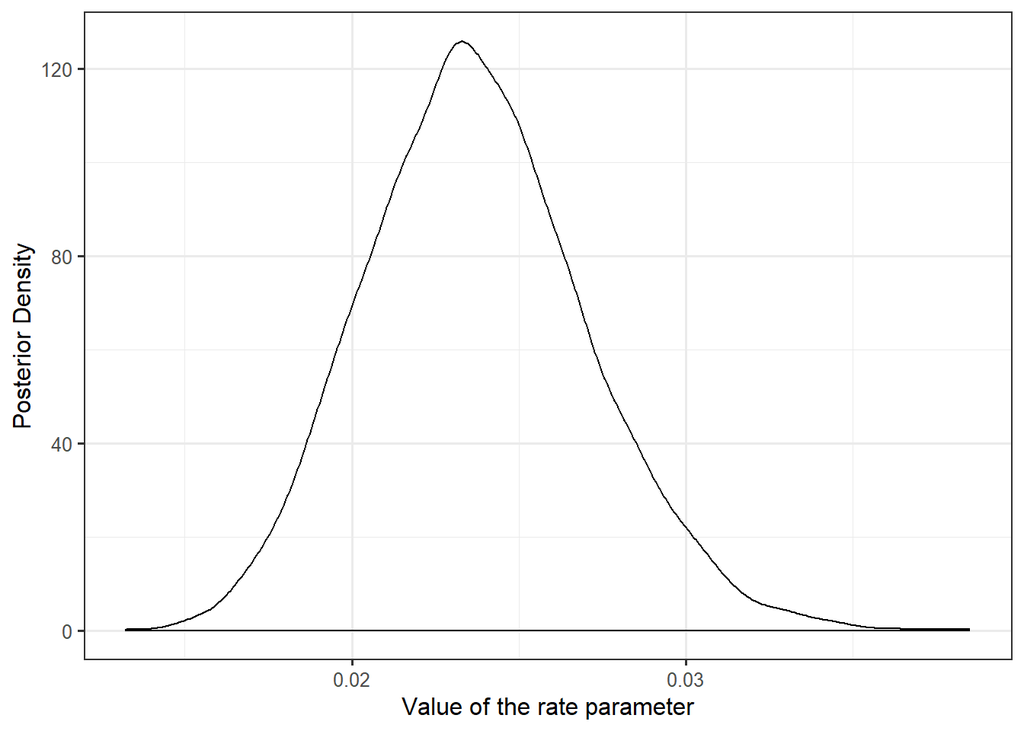

```r
qplot(data = params,
      x = lambda,
      geom = "density") +
  labs(y = "Posterior Density",
       x = "Value of the rate parameter")
```

This occurs so frequently, we can use a special built-in function from the `rstan` package. Notice that it creates structures that can be modified similarly to `qplot()`.

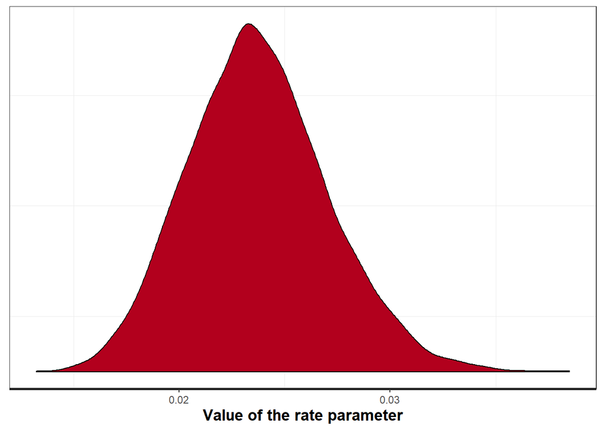

```r
stan_dens(fit, pars = "lambda") +
  labs(x = "Value of the rate parameter")
```

If you wanted to examine the posterior distribution by chain, to get a feel for the mixing, we can do this by using the `separate_chains = TRUE` option.

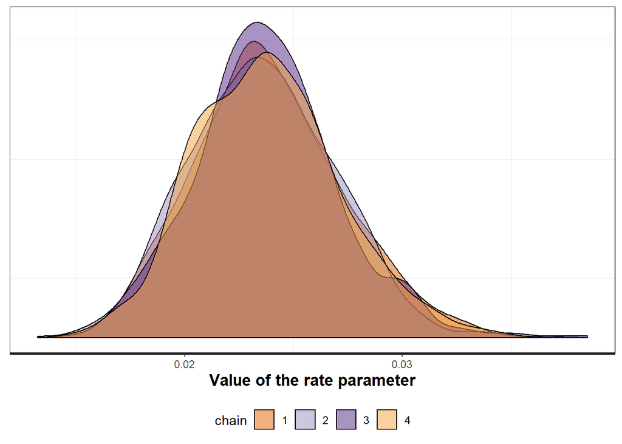

```r
stan_dens(fit, pars = "lambda", separate_chains = TRUE) +
  labs(x = "Value of the rate parameter")
```

## Diagnostic Checks

The first diagnostic that most people want to consider is the traceplot to make sure the various chains mixed properly and that convergence was achieved. This can be done using the `stan_trace()` function from the `rstan` package.

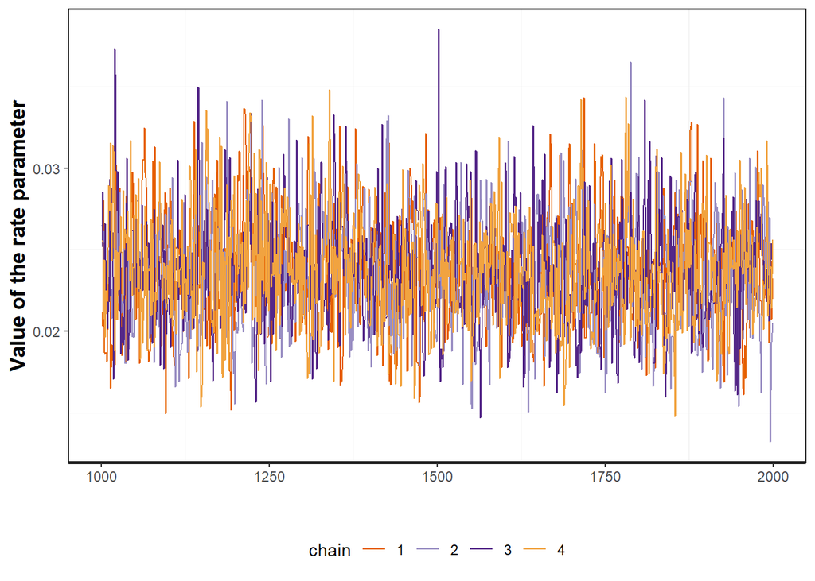

```r
stan_trace(fit, pars = "lambda") +
  labs(y = "Value of the rate parameter")
```

Sometimes, we include the burn-in period as a comparison to see how long it took for mixing to occur.

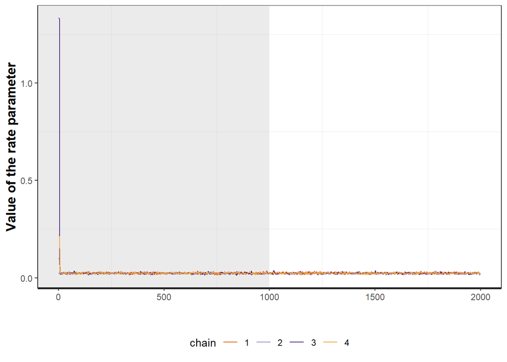

```r
stan_trace(fit, pars = "lambda", inc_warmup = TRUE) +
  labs(y = "Value of the rate parameter")
```

Another check for mixing is the R-hat value, which is found in the standard output.

```
Inference for Stan model: stan-e081fb25e1b.
4 chains, each with iter=2000; warmup=1000; thin=1;
post-warmup draws per chain=1000, total post-warmup draws=4000.

          mean se_mean   sd    2.5%     25%     50%     75%   97.5% n_eff Rhat
lambda    0.02    0.00 0.00    0.02    0.02    0.02    0.03    0.03  1598    1
lp__   -242.31    0.02 0.71 -244.37 -242.48 -242.03 -241.86 -241.81  1921    1

Samples were drawn using NUTS(diag_e) at Mon Jan 20 11:29:24 2020.
For each parameter, n_eff is a crude measure of effective sample size,
and Rhat is the potential scale reduction factor on split chains (at
convergence, Rhat=1).
```

Finally, specific to the type of algorithm we are implementing for the HMC procedure, we should check for divergent iterations. This can be done through the function `check_hmc_diagnostics()` function.

```r
check_hmc_diagnostics(fit)
```

```
Divergences:
```

```
0 of 4000 iterations ended with a divergence.
```

```
Tree depth:
```

```
0 of 4000 iterations saturated the maximum tree depth of 10.
```

```
Energy:
```

```
E-BFMI indicated no pathological behavior.
```

As the output has no iterations with divergence, we can feel confident in our results.

# Bridge Sampling

Bridge sampling is a technique for sampling from the prior predictive distribution (the marginal distribution of the data). The marginal distribution of the data is not generally all that helpful. However, when comparing models, determining the amount of evidence for a model $Pr\left(\mathcal{M}_1 \mid \mathbf{y}\right)$ is similar to sampling from the marginal distribution of the data. This is when bridge sampling is helpful. The details of its implementation are beyond the scope of the course, but it is easily done in R using the `bridgesampling` package. The primary function we use is `bridge_sampler()`.

For a `stanfit` object, for example `fit` from the previous section, we can use the `bridge_sampler()` function to perform bridge sampling.

```r
evidence <- bridge_sampler(fit, silent = TRUE)

evidence$logml
```

By grabbing the `$logml` component, we are obtaining the log of the marginal likelihood. Considering the difference between the logarithm of the marginal likelihoods provides the log Bayes Factor comparing two models.

**Important:** In order to use the `bridge_sampler()` function, you must have Stan code that does *not* use “sampling notation.” That is, the Stan code for the `fit` object above would need to be written as follows (as opposed to as above):

```stan
data{
  int<lower = 0> n;
  real<lower = 0> y[n];
}

parameters{
  real<lower = 0> lambda;
}

model{
  target += gamma_lpdf(lambda | 1, 1);
  target += exponential_lpdf(y | lambda);
}
```

If you have two models, `fit0` and `fit1`, you can obtain Bayes Factors either through

```r
bf(fit0, fit1)
```

or through

```r
fit0$logml - fit1$logml
```

If you want posterior probabilities, you can do

```r
post_prob(fit0, fit1, model_names = c("H0", "H1"))
```

This assumes equal prior probabilities on the models.

# Frequently Asked Questions

There are some things students run into a lot. Here are some common situations.

## I just want to look at my dataset; how?

The easiest way is to go to the “Environment” tab in RStudio and double-click on the name of the dataset. It will open a spread-sheet like interface for looking at your dataset.

## My variable name has spaces and R does not like it!

Variable names which have spaces in them need to be wrapped in back ticks. Technically, all variable names can be done this way, but it is a requirement when the variable name has spaces. For example, the following is allowed:

```r
mtcars = mtcars %>%
  mutate(`Miles Per Gallon` = mpg)
```

## Why does my code block not have a green arrow?

A code block should be completely separate from surrounding text. So, be sure there is a blank line both before the code block and after it. Usually, this fixes the problem.

## How can I make a caption for my graphic?

In your code chunk, include the `fig.cap` option. For example, a code chunk might look like the following:

````
```{r, fig.cap="Relationship between fuel efficiency and the horsepower of a vehicle."}
qplot(data = mtcars
      x = hp
      y = mpg) +
  labs(x = "Horse Power",
       y = "Miles per Gallon")
```
````

This block would produce the following image (notice caption below image):

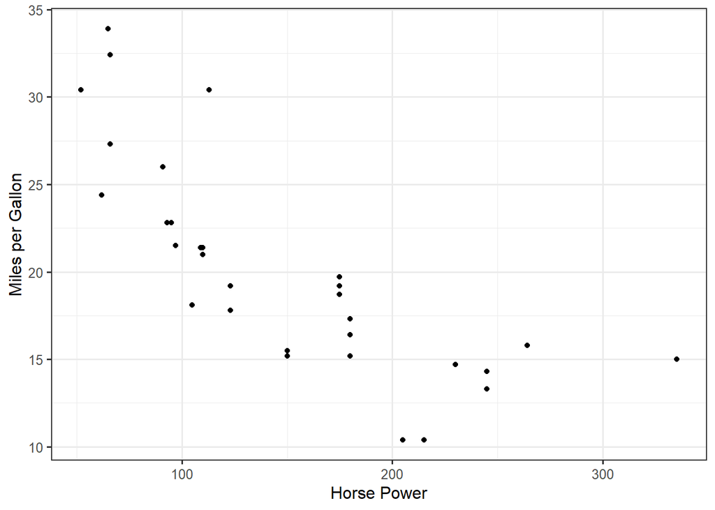

Relationship between fuel efficiency and the horsepower of a vehicle.

## R is not treating my “grouping” variable correctly!

Generally, this happens when your “grouping” variable is a number instead of a phrase. For example, in the `mtcars` dataset, the variable `cyl` takes values 4, 6, or 8. However, R does not know that these values represent groups instead of actual values. In order to get the program to recognize it as a group, rewrite the variable using `factor()`:

```r
mtcars = mtcars %>%
  mutate(cyl = factor(cyl))
```

Now, `cyl` will be treated as a grouping variable. This needs to be done only once and will work for all subsequent graphics and models constructed.

Note: you could also recode the variable manually if you wanted to:

```r
mtcars = mtcars %>%
  mutate(cyl = recode(cyl,
                      `4` = "4 Cylinder",
                      `6` = "6 Cylinder",
                      `8` = "8 Cylinder"))
```

The choice is yours.